# Caseoppgave

Forfatter

Sverre Langaas

Publisert

November 26, 2023

**Kode**

```r
library(tidymodels)
library(reactable)
library(plotly)
library(tictoc)
df <- rchallenge::german %>%
  as_tibble()
```

## Innleding

Jeg vil begynne med å forstå hvor data kommer fra og hva kolonner representer. Det er noe dokumentasjon av datasettet [her](https://archive.ics.uci.edu/dataset/522/south+german+credit). Data er et utvalg fra tyske finansinstitusjoner fra 1973-1975, og det er verdt å merke å merke at:

1. De oversampler antall som misligholder
2. Det er kunder som har fått tilgang til kreditt. Resultater fra modell bør derfor ikke generaliseres til kredittvurdering av nye kunder.

## Utforskende dataanlayse

Vi har litt ulike funksjoner for å få oversikt over datasettet.

**Kode**

```r
glimpse(df)
```

```
Rows: 1,000
Columns: 21
$ status                  <fct> no checking account, no checking account, ... …
$ duration                <int> 18, 9, 12, 12, 12, 10, 8, 6, 18, 24, 11, 30, 6…
$ credit_history          <fct> all credits at this bank paid back duly, all c…
$ purpose                 <fct> car (used), others, retraining, others, others…
$ amount                  <int> 1049, 2799, 841, 2122, 2171, 2241, 3398, 1361,…
$ savings                 <fct> unknown/no savings account, unknown/no savings…
$ employment_duration     <fct> < 1 yr, 1 <= ... < 4 yrs, 4 <= ... < 7 yrs, 1 …
$ installment_rate        <ord> < 20, 25 <= ... < 35, 25 <= ... < 35, 20 <= ..…
$ personal_status_sex     <fct> female : non-single or male : single, male : m…
$ other_debtors           <fct> none, none, none, none, none, none, none, none…
$ present_residence       <ord> >= 7 yrs, 1 <= ... < 4 yrs, >= 7 yrs, 1 <= ...…
$ property                <fct> car or other, unknown / no property, unknown /…
$ age                     <int> 21, 36, 23, 39, 38, 48, 39, 40, 65, 23, 36, 24…
$ other_installment_plans <fct> none, none, none, none, bank, none, none, none…
$ housing                 <fct> for free, for free, for free, for free, rent, …
$ number_credits          <ord> 1, 2-3, 1, 2-3, 2-3, 2-3, 2-3, 1, 2-3, 1, 2-3,…
$ job                     <fct> skilled employee/official, skilled employee/of…
$ people_liable           <fct> 0 to 2, 3 or more, 0 to 2, 3 or more, 0 to 2, …
$ telephone               <fct> no, no, no, no, no, no, no, no, no, no, no, no…
$ foreign_worker          <fct> no, no, no, yes, yes, yes, yes, yes, no, no, n…
$ credit_risk             <fct> good, good, good, good, good, good, good, good…
```

Vi har i hovedsak faktorvariabler. De som har entydig rangering er kodet inn som ordinale variabler.

`skim` gir bedre oversikt. Da får vi blant annet antall manglende verdier, antall unike verdier og fordelingene.

**Kode**

```r
# har utelatt output fordi den tar mye plass
skimr::skim(df)
```

Jeg er i utgangspunktet mest interessert i den betingede fordelingen av `credit_risk` for de ulike variablene. For kontinuerlige variabler kan vi bruke `ggpairs`

**Kode**

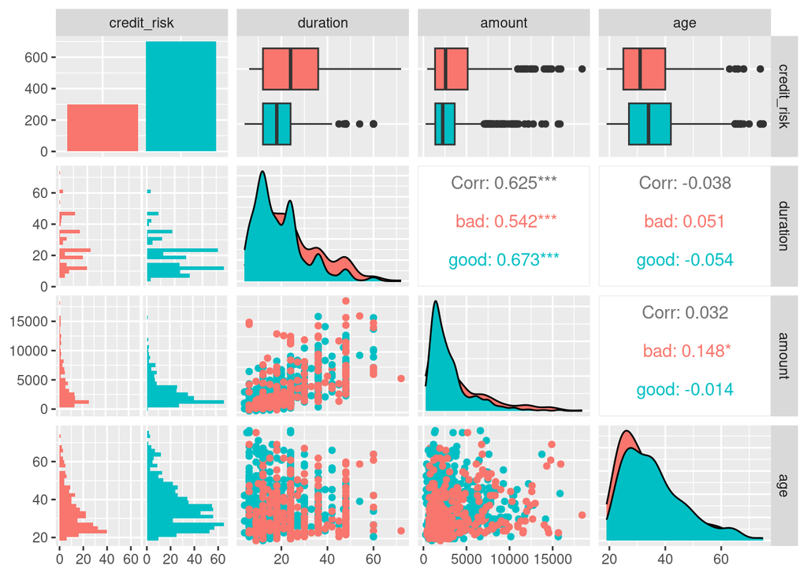

```r
df %>%
  select(credit_risk, where(is.numeric)) %>%
  GGally::ggpairs(aes(color = credit_risk))
```

Det er en kompakt figur med mye informasjon. Vi ser blant annet at lån med lengre nedbetalingstid har større andel med `credit_risk == bad`. Dette gir litt intuitiv mening siden lånetagere som velger kortere tid signaliserer evne og vilje til å betale. Det er også større andel blant yngre lånetagere.

Vi ser også antydning til at sammenheng mellom kort nedbetalingstid og lav risiko er større for eldre lånetagere. For å fange opp slike sammenhenger i modellen kan vi lage interaksjonsledd eller på andre måter generere nye variabler. Det er et eksempel på *feature engineering*.

For å se på de kategoriske variablene bruker jeg en tabell.

**Kode**

```r
tmp <- df %>%
  select(where(is.factor)) %>%
  mutate(across(everything(), as.character)) %>%
  pivot_longer(
    cols = -c(credit_risk),
    names_to = "variable",
    values_to = "value",
  ) %>%
  group_by(variable, value, credit_risk) %>%
  summarise(n = n()) %>%
  mutate(n_tot =  sum(n),
         frac_bad = n / n_tot) %>%
  filter(credit_risk == "bad") %>%
  rename(n_bad = n)

tmp %>%
  select(-credit_risk) %>%
  reactable(
    columns = list(
      variable = colDef(
        filterable = TRUE
      ),
      frac_bad = colDef(
        format = colFormat(
          percent = TRUE,
          digits = 2
        )
      )
    )
  )
```

| variable | value | n_bad | n_tot | frac_bad |
| --- | --- | --- | --- | --- |
| credit_history | all credits at this bank paid back duly | 50 | 293 | 0.170648464163823 |
| credit_history | critical account/other credits elsewhere | 28 | 49 | 0.571428571428571 |
| credit_history | delay in paying off in the past | 25 | 40 | 0.625 |
| credit_history | existing credits paid back duly till now | 28 | 88 | 0.318181818181818 |
| credit_history | no credits taken/all credits paid back duly | 169 | 530 | 0.318867924528302 |
| employment_duration | 1 <= ... < 4 yrs | 104 | 339 | 0.306784660766962 |
| employment_duration | 4 <= ... < 7 yrs | 39 | 174 | 0.224137931034483 |
| employment_duration | < 1 yr | 70 | 172 | 0.406976744186047 |
| employment_duration | >= 7 yrs | 64 | 253 | 0.25296442687747 |
| employment_duration | unemployed | 23 | 62 | 0.370967741935484 |

[output cut: 58 more lines]

Den viser blant annet at kreditthistorien er en informativ variabel. Merk at tabellen viser marginale betingede fordelinger, men vi er interessert i å lære om egenskapene til fordelingen betinget av all den tilgjengelige informasjonen. Da trenger vi en modell.

## Modell

Vi vil estimere $f(\mathbf{x}) = P(credit\_risk = bad |x_1, \ldots, x_K)$, der $x_k$ er variabel i datasettet. Det er finnes ulike statistiske metoder for å estimere dette, med ulike fordeler og ulemper. Jeg vil ta utgangspunkt i logistisk regresjon som gir en parametrisk representasjon av funksjonen, $f(\mathbf{x})=\Lambda(\mathbf{x}'\beta)$.

Vi begynner alltid med å splitte i trenings- og testdata. Målet vårt er å generalisere til nye observasjoner, ikke memorisere de vi har. For å evaluere modell må vi teste på data den ikke har blitt trent på.

**Kode**

```r
set.seed(1)
df_split <- initial_split(df)
df_train <- training(df_split)
df_test <- testing(df_split)
```

**Kode**

```r
logreg_recipe <- recipe(credit_risk ~ ., data = df_train)

logreg_spec <- logistic_reg()

logreg_wf <- workflow() %>%
  add_recipe(logreg_recipe) %>%
  add_model(logreg_spec)

logreg_wf_fit <- logreg_wf %>%
  fit(df_train)
```

**Treningsdata**

**Kode**

```r
train_conf_mat <- logreg_wf_fit %>%
  augment(df_train) %>%
  conf_mat(truth = credit_risk, estimate = .pred_class)

train_conf_mat
```

```
          Truth
Prediction bad good
      bad  126   54
      good  99  471
```

**Kode**

```r
train_conf_mat %>%
  summary() %>%
  filter(.metric %in% c("accuracy", "sens", "spec"))
```

```
# A tibble: 3 × 3
  .metric  .estimator .estimate
  <chr>    <chr>          <dbl>
1 accuracy binary         0.796
2 sens     binary         0.56
3 spec     binary         0.897
```

**Kode**

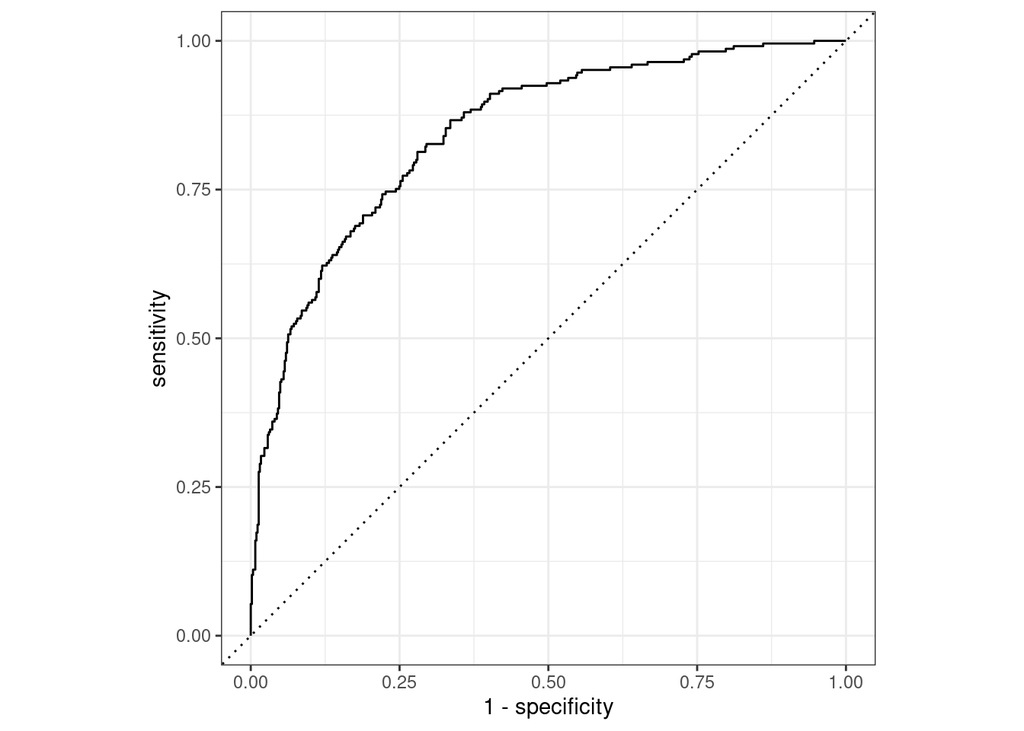

```r
logreg_wf_fit %>%
  augment(df_train) %>%
  roc_curve(credit_risk, .pred_bad) %>%
  autoplot()
```

**Testdata**

**Kode**

```r
train_conf_mat <- logreg_wf_fit %>%
  augment(df_test) %>%
  conf_mat(truth = credit_risk, estimate = .pred_class)

train_conf_mat
```

```
          Truth
Prediction bad good
      bad   36   25
      good  39  150
```

**Kode**

```r
train_conf_mat %>%
  summary() %>%
  filter(.metric %in% c("accuracy", "sens", "spec"))
```

```
# A tibble: 3 × 3
  .metric  .estimator .estimate
  <chr>    <chr>          <dbl>
1 accuracy binary         0.744
2 sens     binary         0.48
3 spec     binary         0.857
```

**Kode**

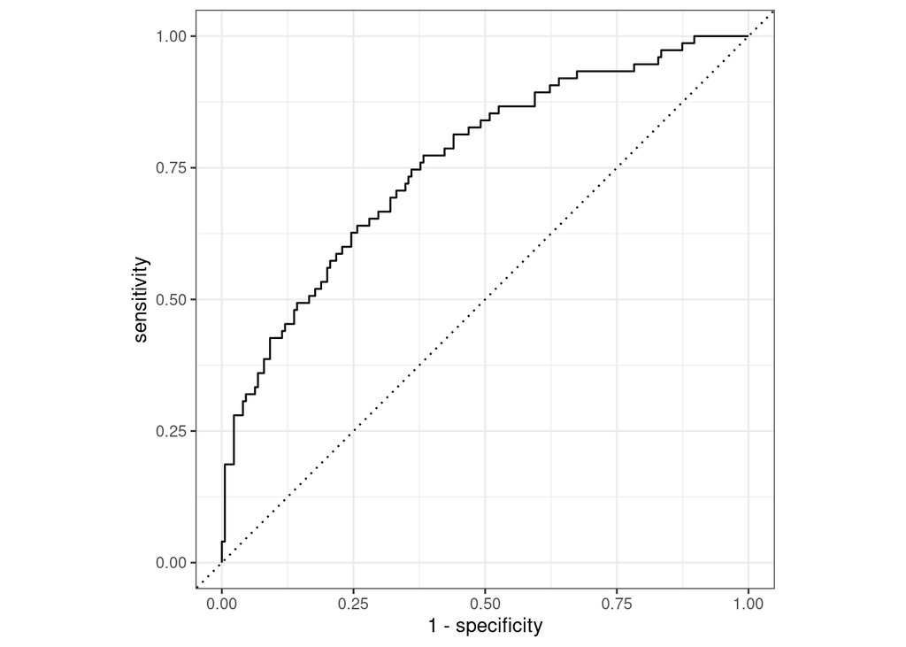

```r
logreg_wf_fit %>%
  augment(df_test) %>%
  roc_curve(credit_risk, .pred_bad) %>%
  autoplot()
```

Øverst vises *confusion matrix* og noen tallmål som er utledet fra den. Det tar utgangspunkt at vi bruker predikerer utfallet som har høyest estimert sannsynlighet.

Under vises *ROC* som viser tradeoff mellom sensitivitet og spesitivitet for ulike *tresholds*. Hvis vi er mer opptatt av å korrekt predikere `credit_risk = bad` så kunne vi valgt lavere treshold.

Den fungerer betydelig bedre på treningsdata enn testdata. Det tyder på at den *overfitter* som gir mening ettersom det er mange variabler i forhold til antall observasjoner.

## Videreutvikling av modell

For å gjøre det enklere for andre å sette seg inn i og videreutvikle modellen bør arbeidet være strukturert og dokumentert. Det er kostnader ved å skrive dokumentasjon og den kan bli utdatert over tid, så det er noen avveininger her. Som minimum bør utforskende dataanlyse og annet forarbeid bli bevart i egne dokumenter som er atskilt fra selve modellen. Mer teknisk dokumentasjon bør vært knyttet til selve koden slik at det er enklere å oppdatere de samtidig.

Koden bør være strukturert slik at den er enkel å lese og gjøre endringer på, for eksempel ved å unngå unnødvendig repetisjon og hardkoding av verdier.